# Examen methode simulation

Guangyue

# Exerccise 1

### Q1

la simulation de X

```r
#simuler un seal valeur de X
simul<-function(){
  X=c(-0.5,-1,1.5,2)
  P=c(1/4,1/4,1/8,3/8)
  C<-c(P[1])
  for (i in 2:4){
    C<-c(C,C[i-1]+P[i])
  }
  k<-1
  u<-runif(1,0,1)
  while(u>C[k]){
    k<-k+1
  }
  return (X[k])
}


#simuler n valeurs de X
create_echantillon<-function(n){

echantillon=c()
for (i in 1:n){
  echantillon<-c(echantillon,simul())
}

return(echantillon)
}
```

```r
TCL <- function(n,simu) {
  mu<- (-0.5)*1/4-1*1/4+1.5*1/8+2*3/8
  ex2<-  0.5^2*1/4+1*1/4+1.5^2*1/8+2^2*3/8
  sigma<-ex2-mu^2
  Xn <- sum(simu) / n
  return((sqrt(n)*(Xn-mu))/(sigma))
}
```

```r
echan_Zn<-function(n,N){
  Z<-TCL(n,create_echantillon(n))
  N=N-1
  for(i in 1:N){

Z<-c(Z,TCL(n,create_echantillon(n)))

  }
  return(Z)


}
```

for Zn n=10 N=10

```r
Z1<-echan_Zn(n=10,N=10)
Z1
```

```
##  [1] -0.46704409  0.06672058  0.06672058 -0.02224019  1.57905381
##  [6]  0.51152447 -0.64496564  0.42256370 -0.91184798  0.06672058
```

for Zn n=30 N=10

```r
Z2<-echan_Zn(n=30,N=10)
Z2
```

```
##  [1]  0.2182865  0.1669250 -0.5521364 -1.0143902  0.8346248 -0.5007749
##  [7]  0.9373479 -0.9116671  0.7319018 -0.7575826
```

for Zn n=40 N=10

```r
Z3<-echan_Zn(n=40,N=10)
Z3
```

```
##  [1]  0.35584311 -1.24545089 -0.08896078  1.20097050  0.08896078
##  [6] -1.51233323 -0.44480389  0.57824506 -0.88960778 -0.84512739
```

```r
Z1<-echan_Zn(n=10,N=100000)
```

```r
Z2<-echan_Zn(n=30,N=100000)
```

```r
Z3<-echan_Zn(n=40,N=100000)
```

density

```r
ab <- -4
current = ab + 1/10000
for(i in 1:99999) {
  ab <- c(ab, current)
  current = current + 1/10000
}

y <- vector("numeric", 100000)
density <- function(x) {
  return((exp((-x*x)/2))/(sqrt(2*3.14)))
}
for (i in 1:100000) {
  y[i] = density(ab[i])
}
```

graph pour n=10

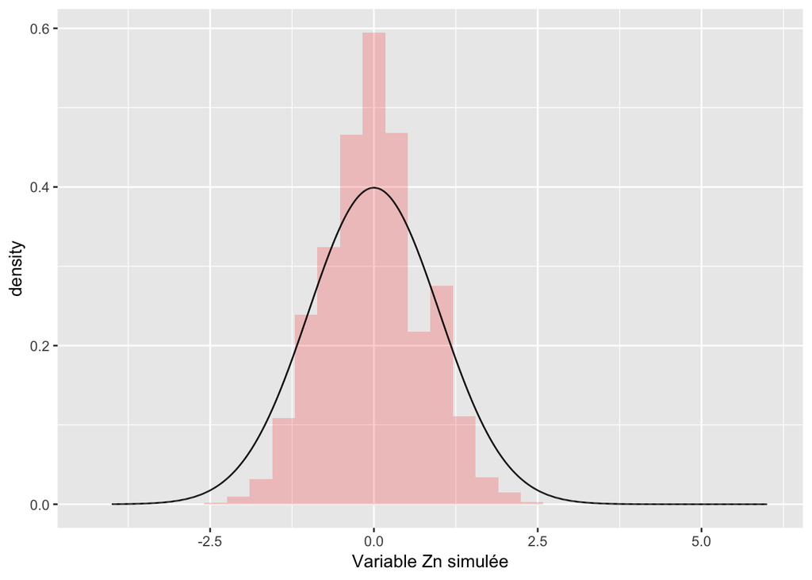

```r
DF1 <- data.frame(Z1,y)
plot1 <- ggplot(DF1,aes(x=DF1$Z1)) +
  geom_histogram(aes(y=..density..),fill = "red", alpha = 0.2) +
  geom_line(aes(x=ab, y=DF1$y)) + xlab("Variable Zn simulée")
plot1
```

graph pour n=30

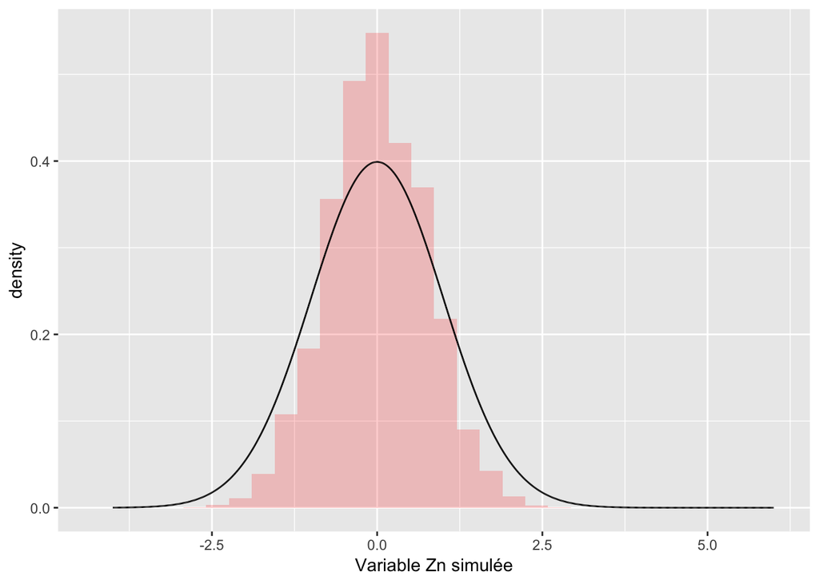

```r
DF2 <- data.frame(Z2,y)
plot2 <- ggplot(DF2,aes(x=DF2$Z2)) +
  geom_histogram(aes(y=..density..),fill = "red", alpha = 0.2) +
  geom_line(aes(x=ab, y=DF2$y)) + xlab("Variable Zn simulée")
plot2
```

graph pour n=40

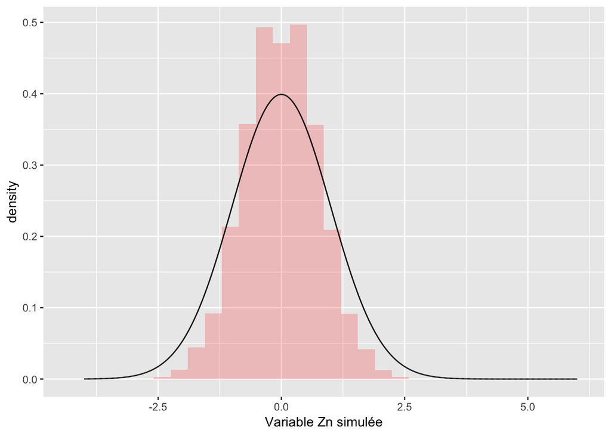

```r
DF3 <- data.frame(Z3,y)
plot3 <- ggplot(DF3,aes(x=DF3$Z3)) +
  geom_histogram(aes(y=..density..),fill = "red", alpha = 0.2) +
  geom_line(aes(x=ab, y=DF3$y)) + xlab("Variable Zn simulée")
plot3
```

### Q3 commenter les graphic

We find that, with the bigger value ‘n’, the graph which we get is more simular with the density of normal distribution.

# Exercise 2

### Q1

choisir les sigma_ij

for p=0.05,$\sigma_{11}=0$,$\sigma_{12}=20$,$\sigma_{21}=20$,$\sigma_{22}=1$

Pour p=0.5,$\sigma_{11}=1$,$\sigma_{12}=3$,$\sigma_{21}=5$,$\sigma_{22}=1$

Pour p=0.95,$\sigma_{11}=1$,$\sigma_{12}=1/0.225$,$\sigma_{21}=0.6$,$\sigma_{22}=1$

### Q2 representer le graph

Pour p=0.05

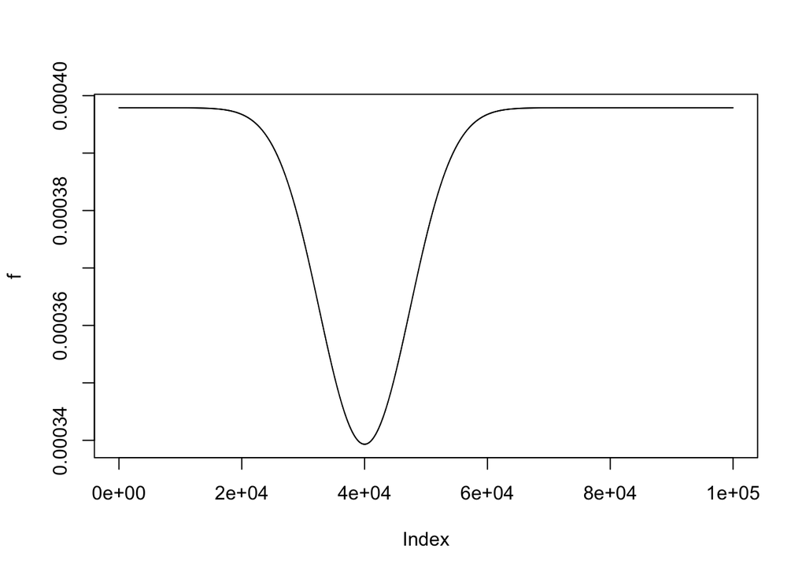

```r
sigma11 <- 0
sigma12 <- 20
sigma21 <- 20
sigma22 <- 1

sigma1 <- sqrt(sigma11*sigma11 + sigma12*sigma12)
sigma2 <- sqrt(sigma21*sigma21 + sigma22*sigma22)

Z1 <- sigma11*y + sigma12 *y
Z2 <- sigma21 * y + sigma22 * y

z=Z1^2/sigma1^2-2*0.05*Z2*Z1/sigma1/sigma2+Z2^2/sigma2^2

f<-1/(2*pi*sigma1*sigma2*sqrt(1-0.05^2))*exp(-z/2/(1-0.05^2))
plot(f,type='l')
```

### Q3

En déduire une simulation de N = 10 réalisations indépendantes de la loi gaussienne Z = (X1,X2)

```r
R <- rexp(1,rate=0.5)
THETA <- runif(1,0,2*3.14)

for (i in 1:9) {
  R <- c(R,rexp(1,rate=0.5))
  THETA <- c(THETA,runif(1,0,2*3.14))
}

X1 = vector("numeric",10)
X2 = vector("numeric",10)

for (i in 1:10) {
  X1[i] = R[i] * cos(THETA[i])
  X2[i] = R[i] * sin(THETA[i])
}
```

Pour p=0.05

```r
sigma11 <- 0
sigma12 <- 20
sigma21 <- 20
sigma22 <- 1

sigma1 <- sqrt(sigma11*sigma11 + sigma12*sigma12)
sigma2 <- sqrt(sigma21*sigma21 + sigma22*sigma22)

Z1 <- sigma11*X1 + sigma12 * X2
Z2 <- sigma21 * X1 + sigma22 * X2

data.frame(Z1,Z2)
```

| Z1 | Z2 |
| --- | --- |
| -8.343673 | 9.57166967 |
| -49.980124 | -32.54652088 |
| 4.329211 | -7.71836774 |
| 15.726737 | -15.25262132 |
| 0.627685 | 0.19204680 |
| 9.341228 | 30.50541330 |
| 1.910756 | 0.19562476 |
| -24.724434 | 19.77304227 |
| -22.151476 | 21.90277430 |
| 10.564579 | -0.09726189 |

Pour p=0.5

```r
sigma11 <- 1
sigma12 <- 3
sigma21 <- 5
sigma22 <- 1

sigma1 <- sqrt(sigma11*sigma11 + sigma12*sigma12)
sigma2 <- sqrt(sigma21*sigma21 + sigma22*sigma22)

Z1 <- sigma11*X1 + sigma12 * X2
Z2 <- sigma21 * X1 + sigma22 * X2

data.frame(Z1,Z2)
```

| Z1 | Z2 |
| --- | --- |
| -0.7521082 | 2.08002969 |
| -8.9993943 | -10.01088486 |
| 0.2526403 | -1.76724652 |
| 1.5570626 | -3.22340269 |
| 0.1021859 | 0.07154989 |
| 2.9031018 | 7.97664937 |
| 0.2916177 | 0.12055953 |
| -2.6582019 | 4.01609430 |
| -2.1722040 | 4.64501322 |
| 1.5534123 | 0.37185624 |

Pour p=0.95

```r
sigma11 <- 1
sigma12 <- 1/0.225
sigma21 <- 0.6
sigma22 <- 1

sigma1 <- sqrt(sigma11*sigma11 + sigma12*sigma12)
sigma2 <- sqrt(sigma21*sigma21 + sigma22*sigma22)

Z1 <- sigma11*X1 + sigma12 * X2
Z2 <- sigma21 * X1 + sigma22 * X2

data.frame(Z1,Z2)
```

| Z1 | Z2 |
| --- | --- |
| -1.3547068 | -0.11751803 |
| -12.6090699 | -3.40043163 |
| 0.5653055 | -0.02158429 |
| 2.6928825 | 0.30516810 |
| 0.1475187 | 0.03620413 |
| 3.5777460 | 1.36821195 |
| 0.4296167 | 0.09854040 |
| -4.4438554 | -0.60594377 |
| -3.7720328 | -0.41726336 |
| 2.3164097 | 0.50946422 |

### Q4

En déduire une simulation de N = 1000 réalisations indépendantes de la loi gaussienne Z = (X1,X2) et représenter les points générés sur R2

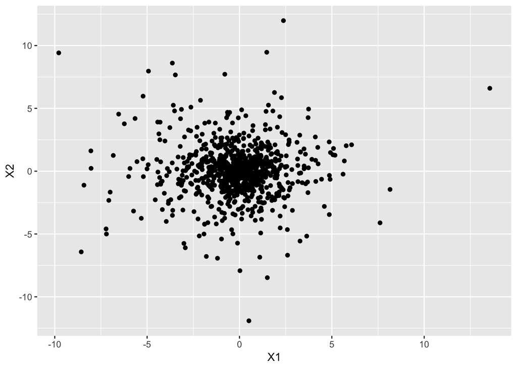

```r
R <- rexp(1,rate=0.5)
THETA <- runif(1,0,2*3.14)

for (i in 1:999) {
  R <- c(R,rexp(1,rate=0.5))
  THETA <- c(THETA,runif(1,0,2*3.14))
}

X1 = vector("numeric",1000)
X2 = vector("numeric",1000)

for (i in 1:1000) {
  X1[i] = R[i] * cos(THETA[i])
  X2[i] = R[i] * sin(THETA[i])
}

DF4 <- data.frame(X1,X2)
plot4 <- ggplot(DF4,aes(x = DF4$X1,y=DF4$X2)) + geom_point() + xlab("X1") + ylab("X2")
plot4
```

Pour p=0.05

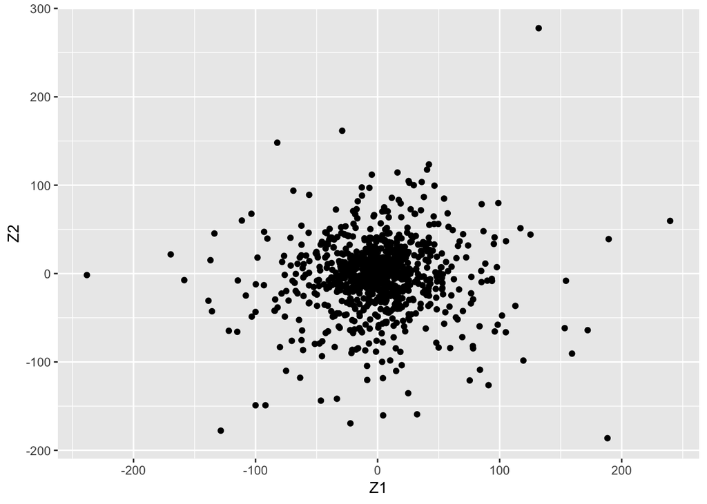

```r
sigma11 <- 0
sigma12 <- 20
sigma21 <- 20
sigma22 <- 1

sigma1 <- sqrt(sigma11*sigma11 + sigma12*sigma12)
sigma2 <- sqrt(sigma21*sigma21 + sigma22*sigma22)

Z1 <- sigma11*X1 + sigma12 * X2
Z2 <- sigma21 * X1 + sigma22 * X2

DF5 <- data.frame(Z1,Z2)
plot5 <- ggplot(DF5,aes(x = DF5$Z1,y=DF5$Z2)) + geom_point() + xlab("Z1") + ylab("Z2")
plot5
```

Pour p=0.5

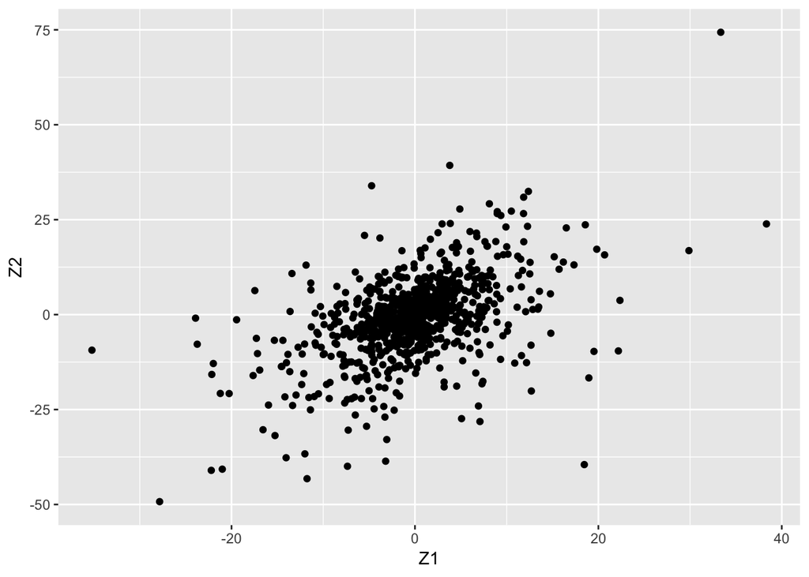

```r
sigma11 <- 1
sigma12 <- 3
sigma21 <- 5
sigma22 <- 1


sigma1 <- sqrt(sigma11*sigma11 + sigma12*sigma12)
sigma2 <- sqrt(sigma21*sigma21 + sigma22*sigma22)

Z1 <- sigma11*X1 + sigma12 * X2
Z2 <- sigma21 * X1 + sigma22 * X2

DF6 <- data.frame(Z1,Z2)
plot6 <- ggplot(DF6,aes(x = DF6$Z1,y=DF6$Z2)) + geom_point() + xlab("Z1") + ylab("Z2")
plot6
```

Pour p=0.95

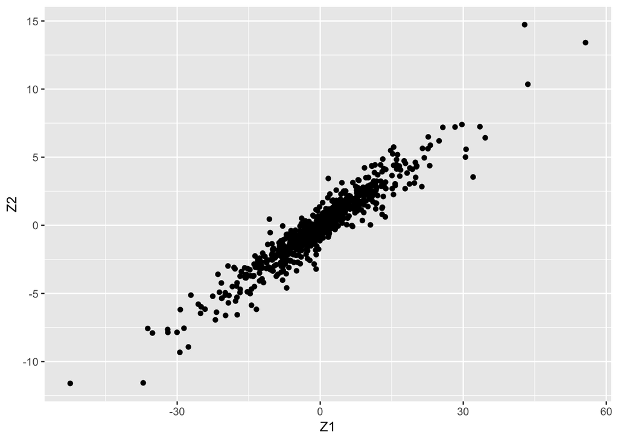

```r
sigma11 <- 1
sigma12 <- 1/0.225
sigma21 <- 0.6
sigma22 <- 1

sigma1 <- sqrt(sigma11*sigma11 + sigma12*sigma12)
sigma2 <- sqrt(sigma21*sigma21 + sigma22*sigma22)

Z1 <- sigma11*X1 + sigma12 * X2
Z2 <- sigma21 * X1 + sigma22 * X2

DF7 <- data.frame(Z1,Z2)
plot7 <- ggplot(DF7,aes(x = DF7$Z1,y=DF7$Z2)) + geom_point() + xlab("Z1") + ylab("Z2")
plot7
```

we find that with the biggervalue ‘p’, the gragh is more inclining to one side.

### Q5

```r
Sigma <- matrix(c(1,1/0.225,0.5,1),2,2)
```

# Exercise 3

### Q1

$$\begin{aligned}
E(Y)&=E(X)=1=\sum_{Y\subset{1,0,-1}}Y*P(Y)\\
&=6*c+(-6)*(1-c-\frac{1}{3})+0*\frac{1}{3}=1\\
c&=\frac{5}{12}
\end{aligned}$$
Donc on $P(Y=6)=\frac{5}{12}$ et $P(Y=-6)=\frac{1}{4}$

### Q2

$$\begin{aligned}
E(Y^2)&=\sum_{Y\subset{1,0,-1}}Y^2*P(Y)\\
&=6^2*\frac{5}{12}+(-6)^2*\frac{1}{4}+0*\frac{1}{3}=24\\
Var(Y)&=E(Y^2)-(E(Y))^2\\
&=24-1^2\\
&=23
\end{aligned}$$

### Q3

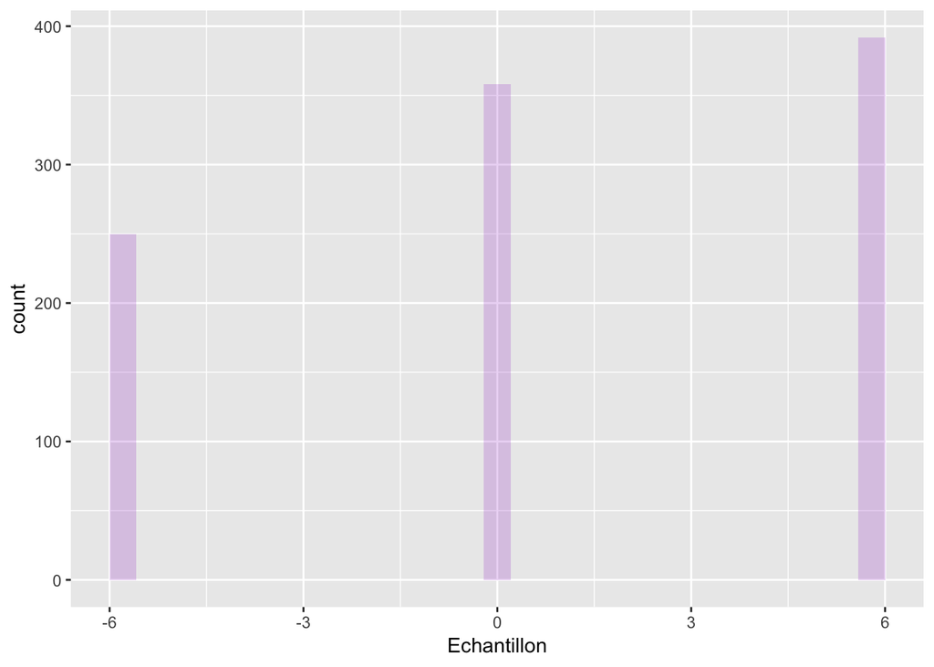

```r
simuY<-function(){
  Y=c(-6,0,6)
  P=c(1/4,1/3,5/12)
  C<-c(P[1])
 C<-c(C,C[1]+P[2])
  C<-c(C,1)
  k<-1
  u<-runif(1,0,1)
  while(u>C[k]){
    k<-k+1
  }
  return (Y[k])
}

N=1000
echantillonY=c()
for (i in 1:1000){
  echantillonY<-c(echantillonY,simuY())
}


dat <- data.frame(echantillonY)
plot8 <- ggplot(dat,aes(x=dat$echantillonY)) + geom_histogram(fill = "darkorchid", alpha = 0.2) + xlab("Echantillon")
plot8
```

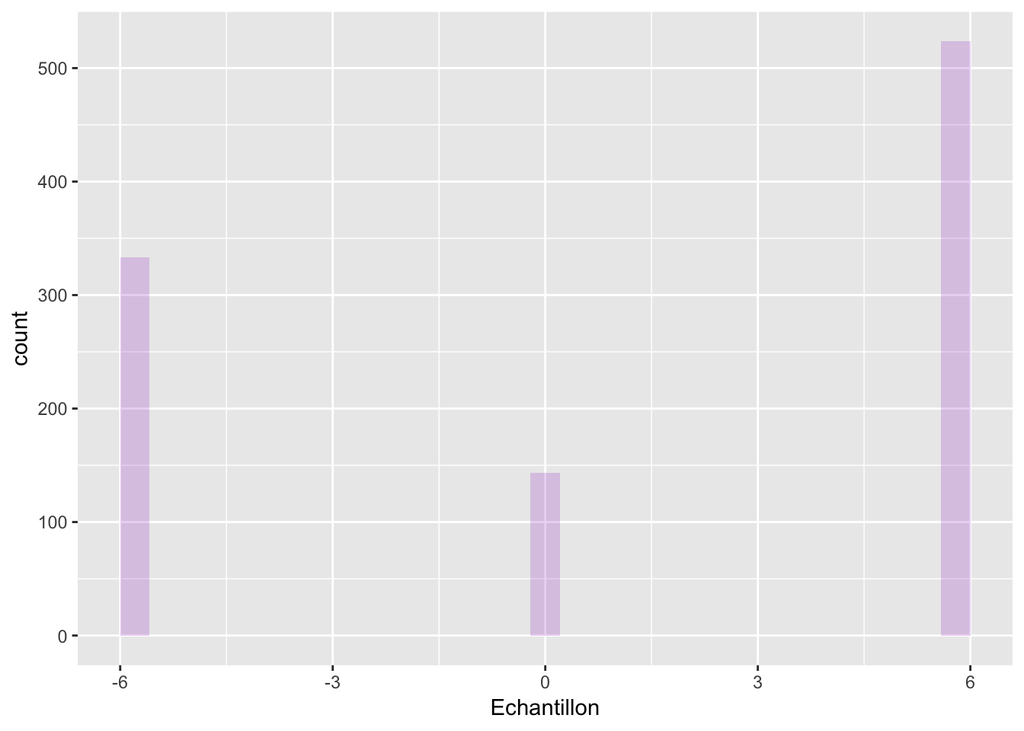

```r
simuX<-function(){
  X=c(-6,0,6)
  P=c(1/3,1/6,1/2)
  C<-c(P[1])
    C<-c(C,C[1]+P[2])
C<-c(C,C[2]+P[3])

  k<-1
  u<-runif(1,0,1)
  while(u>C[k]){
    k<-k+1
  }
  return (X[k])
}
N=1000
echantillonX=c()
for (i in 1:1000){
  echantillonX<-c(echantillonX,simuX())
}


dat2 <- data.frame(echantillonX)
plot8 <- ggplot(dat2,aes(x=dat2$echantillonX))+ geom_histogram(fill = "darkorchid", alpha = 0.2) + xlab("Echantillon")
plot8
```

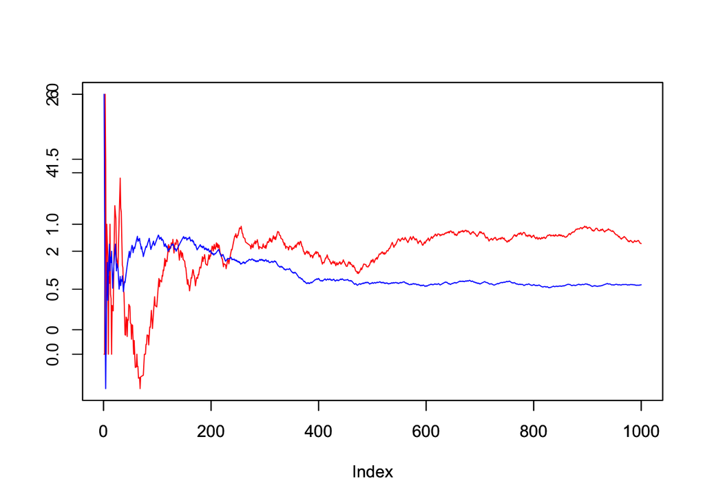

```r
Z_x=c()
for(i in 1:1000){
  Z_x=c(Z_x,mean(echantillonX[1:i]))
}
Z_y=c()
for(i in 1:1000){
  Z_y=c(Z_y,mean(echantillonY[1:i]))
}


plot(Z_y,type='line',col='red',ylab="")
par(new=TRUE)
plot(Z_x,type='line',col='blue',ylab="")
```

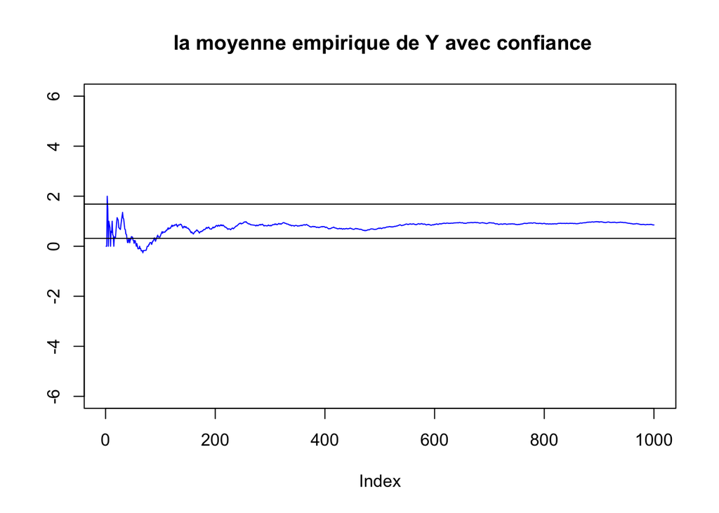

```r
alpha=0.05
c_alpha=qnorm(1-alpha/2)

Sny=0
for(i in 1:1000){
    si=0
  for(j in 1:i){
  si=si+echantillonY[j]^2-2*echantillonY[j]*Z_y[i]+Z_y[i]^2

}
  si=si/999
  Sny=Sny+si
}
Sny=Sny/999
epsY=c_alpha*Sny/sqrt(N)
plot(Z_y,ylim=c(-6,6),type='line',col='blue',ylab="",main=" la moyenne empirique de Y avec confiance")

abline(h=1 +epsY)
abline(h=1-epsY)
```

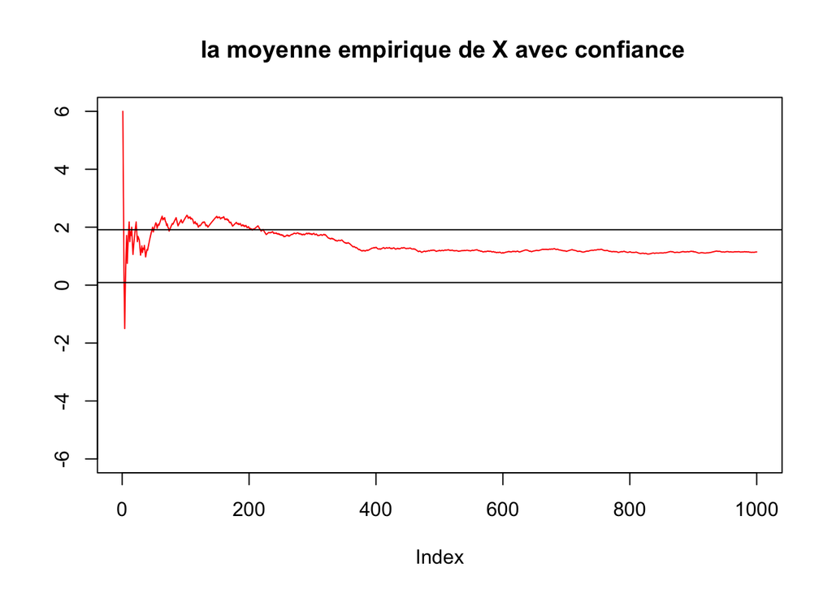

```r
alpha=0.05
c_alpha=qnorm(1-alpha/2)

Snx=0

for(i in 1:1000){
  si=0
  for(j in 1:i){
  si=si+echantillonX[j]^2-2*echantillonX[j]*Z_x[i]+Z_x[i]^2
  }
  si=si/999
  Snx=Snx+si
}
Snx=Snx/999
epsX=c_alpha*Snx/sqrt(N)
plot(Z_x,ylim=c(-6,6),type='line',col='red',ylab="",main=" la moyenne empirique de X avec confiance")

abline(h=1 +epsX)
abline(h=1-epsX)
```

From the two graph ,we find that they converge well.

# Exercise 4

```r
transfer_matrix = t(matrix(c(0.2,0.1,0.5,0.2,
                           0.1,0.6,0.1,0.2,
                           0.3,0.1,0.2,0.4,
                           0.1,0.1,0.1,0.7),4,4))

simu_chain<-function(){
  X=c(1,2,3,4)
  P=c(1/4,1/4,1/4)
  C<-c(P[1])
    C<-c(C,C[1]+P[2])
C<-c(C,C[2]+P[3])
C<-c(C,1)
  k<-1
  u<-runif(1,0,1)
  while(u>C[k]){
    k<-k+1
  }
  return (X[k])
}


chain_initial<-function(n){
  chain=c()
for (i in 1:n){
  chain<-c(chain,simu_chain())
}
  return(chain)
}



mcmove<-function(Q, n,chain){

 for(i in 1:n){
   chain[i]
 }

  return (chain)
}
chain<-chain_initial(1000)
```